# IODS course project

Finally, we can fit a random intercept and slope model that allows for a treatment × week interaction.

```r
# create a random intercept and random slope model with the interaction
BPRS_ref2 <- lmer(bprs ~ week + treatment + week * treatment + (week | subject), data = BPRS, REML = FALSE)

# print a summary of the model
summary(BPRS_ref2)
```

```
## Linear mixed model fit by maximum likelihood  ['lmerMod']
## Formula: bprs ~ week + treatment + week * treatment + (week | subject)
##    Data: BPRS
##
##      AIC      BIC   logLik deviance df.resid
##   2744.3   2775.4  -1364.1   2728.3      352
##
## Scaled residuals:
##     Min      1Q  Median      3Q     Max
## -3.0512 -0.6271 -0.0768  0.5288  3.9260
##
## Random effects:
##  Groups   Name        Variance Std.Dev. Corr
##  subject  (Intercept) 64.9964  8.0620
##           week         0.9687  0.9842   -0.51
##  Residual             96.4707  9.8220
## Number of obs: 360, groups:  subject, 20
##
## Fixed effects:
##                 Estimate Std. Error t value
## (Intercept)      47.8856     2.2521  21.262
## week             -2.6283     0.3589  -7.323
## treatment2       -2.2911     1.9090  -1.200
## week:treatment2   0.7158     0.4010   1.785
##
## Correlation of Fixed Effects:
##             (Intr) week   trtmn2
## week        -0.650
## treatment2  -0.424  0.469
## wek:trtmnt2  0.356 -0.559 -0.840
```

```r
# perform an ANOVA test on the two models
anova(BPRS_ref2, BPRS_ref1)
```

```
## Data: BPRS
## Models:
## BPRS_ref1: bprs ~ week + treatment + (week | subject)
## BPRS_ref2: bprs ~ week + treatment + week * treatment + (week | subject)
##           npar    AIC    BIC  logLik deviance  Chisq Df Pr(>Chisq)
## BPRS_ref1    7 2745.4 2772.6 -1365.7   2731.4
## BPRS_ref2    8 2744.3 2775.4 -1364.1   2728.3 3.1712  1    0.07495 .
## ---
## Signif. codes:  0 '***' 0.001 '**' 0.01 '*' 0.05 '.' 0.1 ' ' 1
```

In this model the treatment is still not significant, as is not the interaction. The likelihood ratio test is not significant, meaning that this model does not improve on the previous one.

Finally we are going to plot the observed values and fitted values of the BPRS_ref1 model.

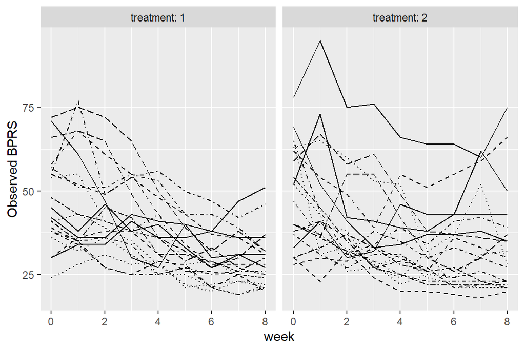

```r
# draw the plot of BPRS with the observed Weight values
ggplot(BPRS, aes(x = week, y = bprs, linetype = subject)) +
  geom_line() +
  scale_linetype_manual(values = rep(1:10, times=4)) +
  facet_grid(. ~ treatment, labeller = label_both) +
  theme(legend.position = "none") +
  scale_y_continuous(limits = c(min(BPRS$bprs), max(BPRS$bprs)), name = "Observed BPRS")
```

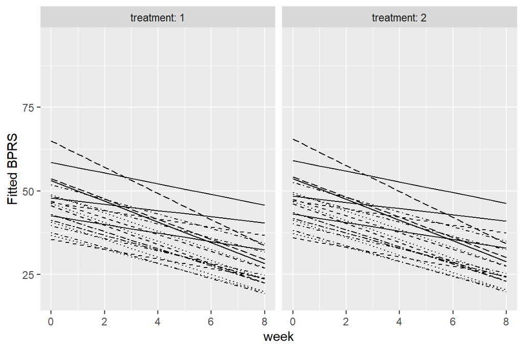

```r
# Create a vector of the fitted values
Fitted <- fitted(BPRS_ref1)

# Create a new column fitted to BPRS
BPRS$Fitted <- Fitted

# draw the plot of RATSL with the Fitted values of weight
ggplot(BPRS, aes(x = week, y = Fitted, linetype = subject)) +
  geom_line() +
  scale_linetype_manual(values = rep(1:10, times=4)) +
  facet_grid(. ~ treatment, labeller = label_both) +
  theme(legend.position = "none") +
  scale_y_continuous(limits = c(min(BPRS$bprs), max(BPRS$bprs)), name = "Fitted BPRS")
```